# STA Exam - MSBA Summer’22

#### (d) Do any of the suburbs of Boston appear to have particularly high crime rates? Tax rates? Pupil-teacher ratios? Comment on the range of each predictor.

```r
Boston %>% summary
```

```
##       crim                zn             indus            chas
##  Min.   : 0.00632   Min.   :  0.00   Min.   : 0.46   Min.   :0.00000
##  1st Qu.: 0.08205   1st Qu.:  0.00   1st Qu.: 5.19   1st Qu.:0.00000
##  Median : 0.25651   Median :  0.00   Median : 9.69   Median :0.00000
##  Mean   : 3.61352   Mean   : 11.36   Mean   :11.14   Mean   :0.06917
##  3rd Qu.: 3.67708   3rd Qu.: 12.50   3rd Qu.:18.10   3rd Qu.:0.00000
##  Max.   :88.97620   Max.   :100.00   Max.   :27.74   Max.   :1.00000
##       nox               rm             age              dis
##  Min.   :0.3850   Min.   :3.561   Min.   :  2.90   Min.   : 1.130
##  1st Qu.:0.4490   1st Qu.:5.886   1st Qu.: 45.02   1st Qu.: 2.100
##  Median :0.5380   Median :6.208   Median : 77.50   Median : 3.207
##  Mean   :0.5547   Mean   :6.285   Mean   : 68.57   Mean   : 3.795
##  3rd Qu.:0.6240   3rd Qu.:6.623   3rd Qu.: 94.08   3rd Qu.: 5.188
##  Max.   :0.8710   Max.   :8.780   Max.   :100.00   Max.   :12.127
##       rad              tax           ptratio          black
##  Min.   : 1.000   Min.   :187.0   Min.   :12.60   Min.   :  0.32
##  1st Qu.: 4.000   1st Qu.:279.0   1st Qu.:17.40   1st Qu.:375.38
##  Median : 5.000   Median :330.0   Median :19.05   Median :391.44
##  Mean   : 9.549   Mean   :408.2   Mean   :18.46   Mean   :356.67
##  3rd Qu.:24.000   3rd Qu.:666.0   3rd Qu.:20.20   3rd Qu.:396.23
##  Max.   :24.000   Max.   :711.0   Max.   :22.00   Max.   :396.90
##      lstat            medv
##  Min.   : 1.73   Min.   : 5.00
##  1st Qu.: 6.95   1st Qu.:17.02
##  Median :11.36   Median :21.20
##  Mean   :12.65   Mean   :22.53
##  3rd Qu.:16.95   3rd Qu.:25.00
##  Max.   :37.97   Max.   :50.00
```

#### (e) How many of the suburbs in this data set bound the Charles river?

```r
Boston %>% filter(chas > 0) %>% count()
```

```
##    n
## 1 35
```

35 suburbs are bounded to river charles

#### (f) What is the median pupil-teacher ratio among the towns in this data set?

```r
Boston %>% str
```

```
## 'data.frame':    506 obs. of  14 variables:
##  $ crim   : num  0.00632 0.02731 0.02729 0.03237 0.06905 ...
##  $ zn     : num  18 0 0 0 0 0 12.5 12.5 12.5 12.5 ...
##  $ indus  : num  2.31 7.07 7.07 2.18 2.18 2.18 7.87 7.87 7.87 7.87 ...
##  $ chas   : int  0 0 0 0 0 0 0 0 0 0 ...
##  $ nox    : num  0.538 0.469 0.469 0.458 0.458 0.458 0.524 0.524 0.524 0.524 ...
##  $ rm     : num  6.58 6.42 7.18 7 7.15 ...
##  $ age    : num  65.2 78.9 61.1 45.8 54.2 58.7 66.6 96.1 100 85.9 ...
##  $ dis    : num  4.09 4.97 4.97 6.06 6.06 ...
##  $ rad    : int  1 2 2 3 3 3 5 5 5 5 ...
##  $ tax    : num  296 242 242 222 222 222 311 311 311 311 ...
##  $ ptratio: num  15.3 17.8 17.8 18.7 18.7 18.7 15.2 15.2 15.2 15.2 ...
##  $ black  : num  397 397 393 395 397 ...
##  $ lstat  : num  4.98 9.14 4.03 2.94 5.33 ...
##  $ medv   : num  24 21.6 34.7 33.4 36.2 28.7 22.9 27.1 16.5 18.9 ...
```

```r
median  = Boston %>%
  dplyr::select(ptratio)  %>%
  mutate(Median = median(ptratio))

median$Median[1]
```

```
## [1] 19.05
```

median is 19.05

#### (g) Which suburb of Boston has lowest median value of owneroccupied homes? What are the values of the other predictors for that suburb, and how do those values compare to the overall ranges for those predictors? Comment on your findings

```r
Boston %>%
  filter(medv == min(medv))
```

```
##      crim zn indus chas   nox    rm age    dis rad tax ptratio  black lstat
## 1 38.3518  0  18.1    0 0.693 5.453 100 1.4896  24 666    20.2 396.90 30.59
## 2 67.9208  0  18.1    0 0.693 5.683 100 1.4254  24 666    20.2 384.97 22.98
##   medv
## 1    5
## 2    5
```

```r
# there are 2 suburbs that have the least medv in the overall dataset.
Boston %>% summary
```

```
##       crim                zn             indus            chas
##  Min.   : 0.00632   Min.   :  0.00   Min.   : 0.46   Min.   :0.00000
##  1st Qu.: 0.08205   1st Qu.:  0.00   1st Qu.: 5.19   1st Qu.:0.00000
##  Median : 0.25651   Median :  0.00   Median : 9.69   Median :0.00000
##  Mean   : 3.61352   Mean   : 11.36   Mean   :11.14   Mean   :0.06917
##  3rd Qu.: 3.67708   3rd Qu.: 12.50   3rd Qu.:18.10   3rd Qu.:0.00000
##  Max.   :88.97620   Max.   :100.00   Max.   :27.74   Max.   :1.00000
##       nox               rm             age              dis
##  Min.   :0.3850   Min.   :3.561   Min.   :  2.90   Min.   : 1.130
##  1st Qu.:0.4490   1st Qu.:5.886   1st Qu.: 45.02   1st Qu.: 2.100
##  Median :0.5380   Median :6.208   Median : 77.50   Median : 3.207
##  Mean   :0.5547   Mean   :6.285   Mean   : 68.57   Mean   : 3.795
##  3rd Qu.:0.6240   3rd Qu.:6.623   3rd Qu.: 94.08   3rd Qu.: 5.188
##  Max.   :0.8710   Max.   :8.780   Max.   :100.00   Max.   :12.127
##       rad              tax           ptratio          black
##  Min.   : 1.000   Min.   :187.0   Min.   :12.60   Min.   :  0.32
##  1st Qu.: 4.000   1st Qu.:279.0   1st Qu.:17.40   1st Qu.:375.38
##  Median : 5.000   Median :330.0   Median :19.05   Median :391.44
##  Mean   : 9.549   Mean   :408.2   Mean   :18.46   Mean   :356.67
##  3rd Qu.:24.000   3rd Qu.:666.0   3rd Qu.:20.20   3rd Qu.:396.23
##  Max.   :24.000   Max.   :711.0   Max.   :22.00   Max.   :396.90
##      lstat            medv
##  Min.   : 1.73   Min.   : 5.00
##  1st Qu.: 6.95   1st Qu.:17.02
##  Median :11.36   Median :21.20
##  Mean   :12.65   Mean   :22.53
##  3rd Qu.:16.95   3rd Qu.:25.00
##  Max.   :37.97   Max.   :50.00
```

These have the highest number of elder population and high levels of nox. And have higher levels of ptratio, black, and tax. These are not the best places to live.

#### (h) In this data set, how many of the suburbs average more than seven rooms per dwelling? More than eight rooms per dwelling? Comment on the suburbs that average more than eight rooms per dwelling.

```r
Boston %>%
  filter(rm > 7) %>% count()
```

```
##    n
## 1 64
```

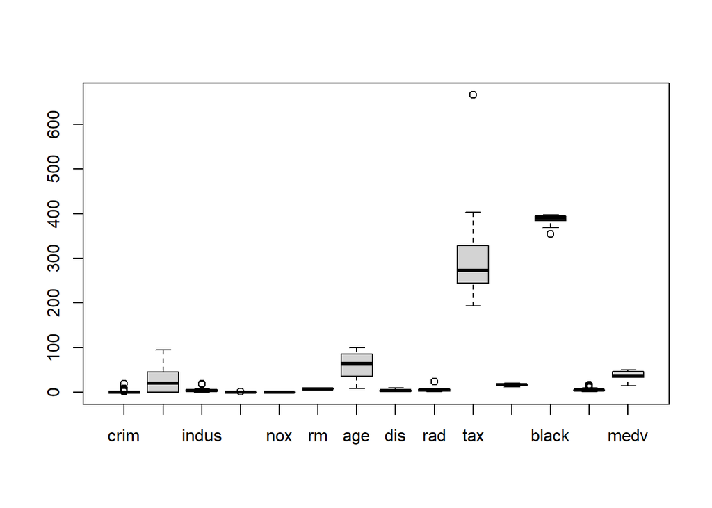

```r
# 64 suburbs average more than 7 rooms per dwelling

Boston %>%
  filter(rm > 7) %>% boxplot()
```

```r
Boston %>%
  filter(rm > 8) %>% count()
```

```
##    n
## 1 13
```

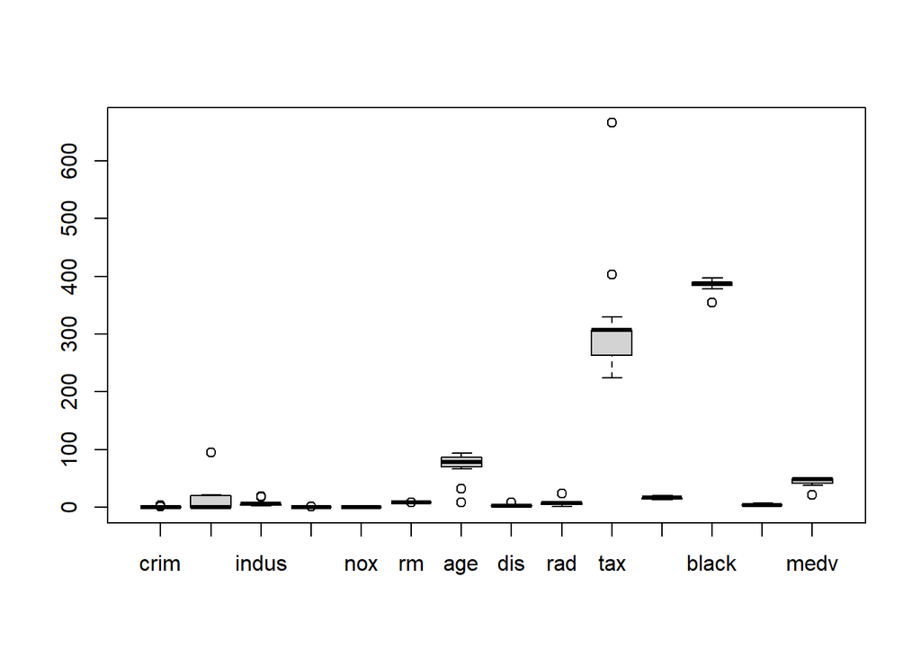

```r
# 13 suburbs average more than 8 rooms per dwelling

Boston %>%
  filter(rm > 8) %>% boxplot()
```

```r
# the taxes and medv on these homes are on the higher side
# compared to more than 7 rooms per dwelling
```

# Chapter 3

### Question 15

This problem involves the Boston data set, which we saw in the lab for this chapter. We will now try to predict per capita crime rate using the other variables in this data set. In other words, per capita crime rate is the response, and the other variables are the predictors

#### (a) For each predictor, fit a simple linear regression model to predict

the response. Describe your results. In which of the models is there a statistically significant association between the predictor and the response? Create some plots to back up your assertions.

```r
rm(list = ls())
library(MASS)
library(tidyverse)
library(knitr)
library(ggplot2)
library(reshape2)
library(broom)

Boston %>% str
```

```
## 'data.frame':    506 obs. of  14 variables:
##  $ crim   : num  0.00632 0.02731 0.02729 0.03237 0.06905 ...
##  $ zn     : num  18 0 0 0 0 0 12.5 12.5 12.5 12.5 ...
##  $ indus  : num  2.31 7.07 7.07 2.18 2.18 2.18 7.87 7.87 7.87 7.87 ...
##  $ chas   : int  0 0 0 0 0 0 0 0 0 0 ...
##  $ nox    : num  0.538 0.469 0.469 0.458 0.458 0.458 0.524 0.524 0.524 0.524 ...
##  $ rm     : num  6.58 6.42 7.18 7 7.15 ...
##  $ age    : num  65.2 78.9 61.1 45.8 54.2 58.7 66.6 96.1 100 85.9 ...
##  $ dis    : num  4.09 4.97 4.97 6.06 6.06 ...
##  $ rad    : int  1 2 2 3 3 3 5 5 5 5 ...
##  $ tax    : num  296 242 242 222 222 222 311 311 311 311 ...
##  $ ptratio: num  15.3 17.8 17.8 18.7 18.7 18.7 15.2 15.2 15.2 15.2 ...
##  $ black  : num  397 397 393 395 397 ...
##  $ lstat  : num  4.98 9.14 4.03 2.94 5.33 ...
##  $ medv   : num  24 21.6 34.7 33.4 36.2 28.7 22.9 27.1 16.5 18.9 ...
```

```r
# ?Boston


predictorlist = colnames(Boston %>% dplyr::select(-crim))

univariate_reg_betas = data.frame()
k = 1
for (i in predictorlist){
  print(i)
  fit <- lm(paste("crim ~", i[[1]]), data=Boston)
  summary_stat = tidy(fit)
  print(summary_stat)
  summary_stat = summary_stat %>% dplyr::select(term, estimate) %>% filter(term == i)
  univariate_reg_betas = rbind(univariate_reg_betas, summary_stat)
}
```

```
## [1] "zn"
## # A tibble: 2 × 5
##   term        estimate std.error statistic  p.value
##   <chr>          <dbl>     <dbl>     <dbl>    <dbl>
## 1 (Intercept)   4.45      0.417      10.7  4.04e-24
## 2 zn           -0.0739    0.0161     -4.59 5.51e- 6
## [1] "indus"
## # A tibble: 2 × 5
##   term        estimate std.error statistic  p.value
##   <chr>          <dbl>     <dbl>     <dbl>    <dbl>
## 1 (Intercept)   -2.06     0.667      -3.09 2.09e- 3
## 2 indus          0.510    0.0510      9.99 1.45e-21
## [1] "chas"
## # A tibble: 2 × 5
##   term        estimate std.error statistic  p.value
##   <chr>          <dbl>     <dbl>     <dbl>    <dbl>
## 1 (Intercept)     3.74     0.396      9.45 1.24e-19
## 2 chas           -1.89     1.51      -1.26 2.09e- 1
## [1] "nox"
## # A tibble: 2 × 5
##   term        estimate std.error statistic  p.value
##   <chr>          <dbl>     <dbl>     <dbl>    <dbl>
## 1 (Intercept)    -13.7      1.70     -8.07 5.08e-15
## 2 nox             31.2      3.00     10.4  3.75e-23
## [1] "rm"
## # A tibble: 2 × 5
##   term        estimate std.error statistic       p.value
##   <chr>          <dbl>     <dbl>     <dbl>         <dbl>
## 1 (Intercept)    20.5      3.36       6.09 0.00000000227
## 2 rm             -2.68     0.532     -5.04 0.000000635
## [1] "age"
## # A tibble: 2 × 5
##   term        estimate std.error statistic  p.value
##   <chr>          <dbl>     <dbl>     <dbl>    <dbl>
## 1 (Intercept)   -3.78     0.944      -4.00 7.22e- 5
## 2 age            0.108    0.0127      8.46 2.85e-16
## [1] "dis"
## # A tibble: 2 × 5
##   term        estimate std.error statistic  p.value
##   <chr>          <dbl>     <dbl>     <dbl>    <dbl>
```

[output cut: 23 more lines]

```
##   <chr>          <dbl>     <dbl>     <dbl>    <dbl>
## 1 (Intercept)  16.6      1.43        11.6  8.92e-28
## 2 black        -0.0363   0.00387     -9.37 2.49e-19
## [1] "lstat"
## # A tibble: 2 × 5
##   term        estimate std.error statistic  p.value
##   <chr>          <dbl>     <dbl>     <dbl>    <dbl>
## 1 (Intercept)   -3.33     0.694      -4.80 2.09e- 6
## 2 lstat          0.549    0.0478     11.5  2.65e-27
## [1] "medv"
## # A tibble: 2 × 5
##   term        estimate std.error statistic  p.value
##   <chr>          <dbl>     <dbl>     <dbl>    <dbl>
## 1 (Intercept)   11.8      0.934      12.6  5.93e-32
## 2 medv          -0.363    0.0384     -9.46 1.17e-19
```

```r
univariate_reg_betas
```

```
## # A tibble: 13 × 2
##    term    estimate
##    <chr>      <dbl>
##  1 zn       -0.0739
##  2 indus     0.510
##  3 chas     -1.89
##  4 nox      31.2
##  5 rm       -2.68
##  6 age       0.108
##  7 dis      -1.55
##  8 rad       0.618
##  9 tax       0.0297
## 10 ptratio   1.15
## 11 black    -0.0363
## 12 lstat     0.549
## 13 medv     -0.363
```

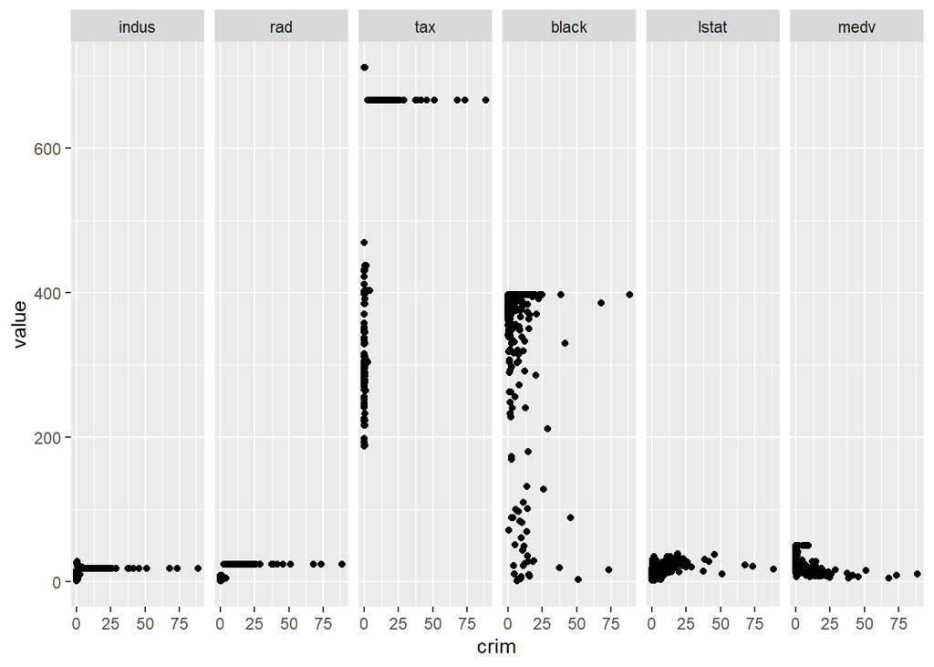

```r
# individually indus, rad, tax, black, lstat and medv have high rsquared. And all metrics are significant (have a pvalue<0.05) except for chas, which isnt significant and its effect can be ignored. the NULL hypothesis for this can be ignored.

# It makes sense to look only at the correlation between these variables and crime rate

boston_subset = Boston %>%
  dplyr::select(crim, indus, rad, tax, black, lstat, medv)

df_melt <- melt(boston_subset,"crim")
#scatter plot per group
ggplot(df_melt, aes(crim,value)) +
  geom_point() +
  facet_grid(.~variable)
```

```r
# These scatter plots show high variability wrt crim rate
```

#### (b) Fit a multiple regression model to predict the response using all of the predictors. Describe your results. For which predictors can we reject the null hypothesis H0 : βj = 0?

```r
lm_fit = lm(crim ~., data=Boston)

lm_fit_tidy = tidy(lm_fit)

lm_fit %>% summary
```

```
##
## Call:
## lm(formula = crim ~ ., data = Boston)
##
## Residuals:
##    Min     1Q Median     3Q    Max
## -9.924 -2.120 -0.353  1.019 75.051
##
## Coefficients:
##               Estimate Std. Error t value Pr(>|t|)
## (Intercept)  17.033228   7.234903   2.354 0.018949 *
## zn            0.044855   0.018734   2.394 0.017025 *
## indus        -0.063855   0.083407  -0.766 0.444294
## chas         -0.749134   1.180147  -0.635 0.525867
## nox         -10.313535   5.275536  -1.955 0.051152 .
## rm            0.430131   0.612830   0.702 0.483089
## age           0.001452   0.017925   0.081 0.935488
## dis          -0.987176   0.281817  -3.503 0.000502 ***
## rad           0.588209   0.088049   6.680 6.46e-11 ***
## tax          -0.003780   0.005156  -0.733 0.463793
## ptratio      -0.271081   0.186450  -1.454 0.146611
## black        -0.007538   0.003673  -2.052 0.040702 *
## lstat         0.126211   0.075725   1.667 0.096208 .
## medv         -0.198887   0.060516  -3.287 0.001087 **
## ---
## Signif. codes:  0 '***' 0.001 '**' 0.01 '*' 0.05 '.' 0.1 ' ' 1
##
## Residual standard error: 6.439 on 492 degrees of freedom
## Multiple R-squared:  0.454,  Adjusted R-squared:  0.4396
## F-statistic: 31.47 on 13 and 492 DF,  p-value: < 2.2e-16
```

#### (c) How do your results from (a) compare to your results from (b)? Create a plot displaying the univariate regression coefficients from (a) on the x-axis, and the multiple regression coefficients from (b) on the y-axis. That is, each predictor is displayed as a single point in the plot. Its coefficient in a simple linear regression model is shown on the x-axis, and its coefficient estimate in the multiple linear regression model is shown on the y-axis.

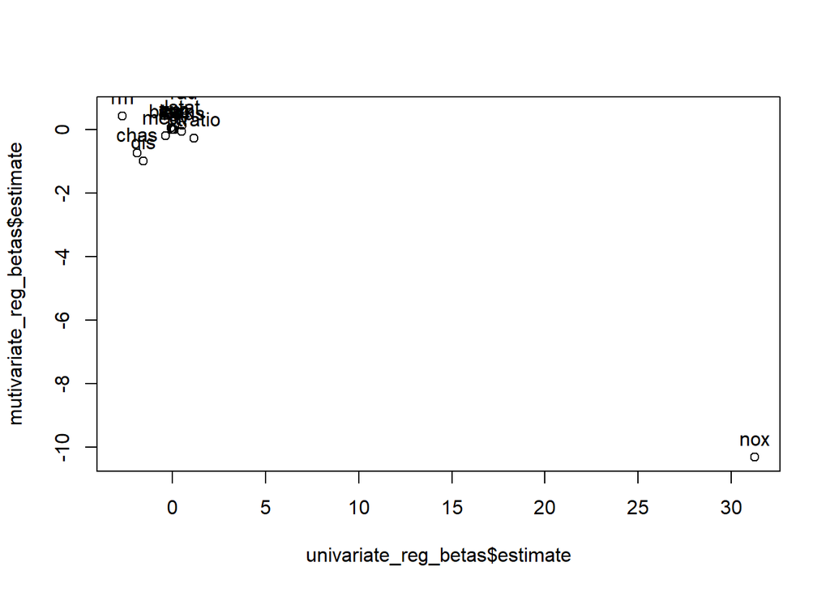

```r
mutivariate_reg_betas = lm_fit_tidy %>% dplyr::select(term, estimate) %>%
  filter(term != "(Intercept)")


plot(x = univariate_reg_betas$estimate, y = mutivariate_reg_betas$estimate)
text(x = univariate_reg_betas$estimate, y = mutivariate_reg_betas$estimate, labels = univariate_reg_betas$term, pos=3)
```

nox is different in multivariate model compared to univariate. it is 31 in univariate and -10 in multivariate

#### (d) Is there evidence of non-linear association between any of the predictors and the response? To answer this question, for each predictor X, fit a model of the form Y = β0 + β1X + β2X2 + β3X3 + E.

```r
predictorlist = colnames(Boston %>% dplyr::select(-crim))

univariate_poly_reg_betas = data.frame()
k = 1
for (i in predictorlist){
  print(i)
  fit = lm(paste("crim ~", i[[1]], "+ I(",i[[1]],"^2) + I(",i[[1]],"^3)"), data=Boston)
  # summary_stat = tidy(fit)
  print(summary(fit))
  summary_stat = summary_stat %>% dplyr::select(term, estimate) %>% filter(term == i)
  univariate_poly_reg_betas = rbind(univariate_poly_reg_betas, summary_stat)
}
```

```
## [1] "zn"
##
## Call:
## lm(formula = paste("crim ~", i[[1]], "+ I(", i[[1]], "^2) + I(",
##     i[[1]], "^3)"), data = Boston)
##
## Residuals:
##    Min     1Q Median     3Q    Max
## -4.821 -4.614 -1.294  0.473 84.130
##
## Coefficients:
##               Estimate Std. Error t value Pr(>|t|)
## (Intercept)  4.846e+00  4.330e-01  11.192  < 2e-16 ***
## zn          -3.322e-01  1.098e-01  -3.025  0.00261 **
## I(zn^2)      6.483e-03  3.861e-03   1.679  0.09375 .
## I(zn^3)     -3.776e-05  3.139e-05  -1.203  0.22954
## ---
## Signif. codes:  0 '***' 0.001 '**' 0.01 '*' 0.05 '.' 0.1 ' ' 1
##
## Residual standard error: 8.372 on 502 degrees of freedom
## Multiple R-squared:  0.05824,    Adjusted R-squared:  0.05261
## F-statistic: 10.35 on 3 and 502 DF,  p-value: 1.281e-06
##
## [1] "indus"
##
## Call:
## lm(formula = paste("crim ~", i[[1]], "+ I(", i[[1]], "^2) + I(",
##     i[[1]], "^3)"), data = Boston)
##
## Residuals:
##    Min     1Q Median     3Q    Max
## -8.278 -2.514  0.054  0.764 79.713
##
## Coefficients:
##               Estimate Std. Error t value Pr(>|t|)
## (Intercept)  3.6625683  1.5739833   2.327   0.0204 *
## indus       -1.9652129  0.4819901  -4.077 5.30e-05 ***
## I(indus^2)   0.2519373  0.0393221   6.407 3.42e-10 ***
## I(indus^3)  -0.0069760  0.0009567  -7.292 1.20e-12 ***
## ---
```

[output cut: 239 more lines]

```
##     Min      1Q  Median      3Q     Max
## -24.427  -1.976  -0.437   0.439  73.655
##
## Coefficients:
##               Estimate Std. Error t value Pr(>|t|)
## (Intercept) 53.1655381  3.3563105  15.840  < 2e-16 ***
## medv        -5.0948305  0.4338321 -11.744  < 2e-16 ***
## I(medv^2)    0.1554965  0.0171904   9.046  < 2e-16 ***
## I(medv^3)   -0.0014901  0.0002038  -7.312 1.05e-12 ***
## ---
## Signif. codes:  0 '***' 0.001 '**' 0.01 '*' 0.05 '.' 0.1 ' ' 1
##
## Residual standard error: 6.569 on 502 degrees of freedom
## Multiple R-squared:  0.4202, Adjusted R-squared:  0.4167
## F-statistic: 121.3 on 3 and 502 DF,  p-value: < 2.2e-16
```

- zn, Indus, Indus^2, Indus^3, nox, nox^2, nox^3, age^2, age^3, dis, dis^2, dis^3, ptratio, ptratio^2, ptratio^3, medv, medv^2, medv^3 are statistically significant.
- chas, rm, rad, tax and their polynomial terms are not significant at all, and none of its polynomial terms are significant

# Chapter 6

### Question 9

In this exercise, we will predict the number of applications received using the other variables in the College data set.

#### (a) Split the data set into a training set and a test set.

```r
rm(list = ls())
library(ISLR)
library(tidyverse)
library(glmnet)
library(pls)

college_dat = College

# splitting dataset with 70:30 split (train-test)
n = college_dat %>% nrow
idx = sample(1:n, 0.7*n)


train = college_dat[idx,]
# length of training set
nrow(train)
```

```
## [1] 543
```

```r
test = college_dat[-idx,]
# length of testing set
nrow(test)
```

```
## [1] 234
```

#### (b) Fit a linear model using least squares on the training set, and report the test error obtained.

```r
lm_fit = lm(Apps~., data = train)


prediction = predict(lm_fit, test%>% dplyr::select(-Apps))

# MSE Error in lm fit
MSE_lm = mean((test[, "Apps"] - prediction)^2)
MSE_lm
```

```
## [1] 1305097
```

#### (c) Fit a ridge regression model on the training set, with λ chosen by cross-validation. Report the test error obtained

```r
train_mat = model.matrix(Apps~., data=train)
test_mat = model.matrix(Apps~., data=test)
grid = 10 ^ seq(4, -2, length=100)

ridge_model = cv.glmnet(train_mat, train[,"Apps"], alpha=0, lambda=grid)
lambda_best = ridge_model$lambda.min
lambda_best
```

```
## [1] 0.01
```

```r
ridge_prediction = predict(ridge_model, newx=test_mat, s=lambda_best)
MSE_ridge = mean((test[, "Apps"] - ridge_prediction)^2)

cat(MSE_ridge)
```

```
## 1305069
```

#### (d) Fit a lasso model on the training set, with λ chosen by cross-validation. Report the test error obtained

```r
lasso_model = cv.glmnet(train_mat, train[,"Apps"], alpha=1, lambda=grid)
lambda_best = lasso_model$lambda.min
lambda_best
```

```
## [1] 28.48036
```

```r
lasso_prediction = predict(lasso_model, newx=test_mat, s=lambda_best)

MSE_lasso = mean((test[, "Apps"] - lasso_prediction)^2)

predict(lasso_model, s=lambda_best, type="coefficients")
```

```
## 19 x 1 sparse Matrix of class "dgCMatrix"
##                        s1
## (Intercept) -692.28306473
## (Intercept)    .
## PrivateYes  -356.66048862
## Accept         1.53633927
## Enroll        -0.32600607
## Top10perc     23.69631835
## Top25perc      .
## F.Undergrad    .
## P.Undergrad    0.01418900
## Outstate      -0.07854668
## Room.Board     0.08867744
## Books          .
## Personal       .
## PhD           -6.71434083
## Terminal      -0.25767855
## S.F.Ratio      2.90161803
## perc.alumni    .
## Expend         0.09487460
## Grad.Rate      6.94658911
```

```r
cat(MSE_lasso)
```

```
## 1242556
```

#### (e) Fit a PCR model on the training set, with M chosen by crossvalidation. Report the test error obtained, along with the value of M selected by cross-validation.

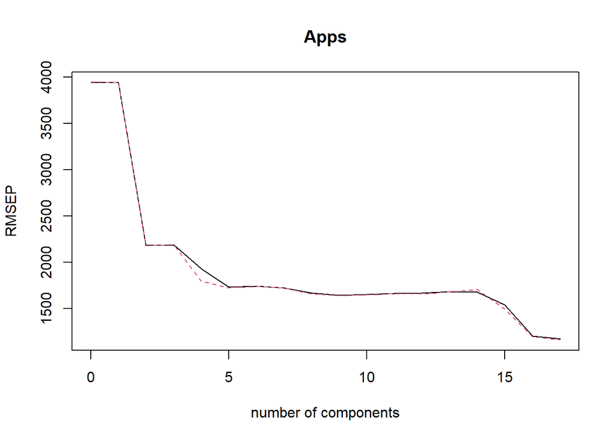

```r
pcr_fit = pcr(Apps~., data=train, scale=T, validation="CV")

cat(validationplot(pcr_fit, val_type="MSEP"))
```

```r
pcr_pred = predict(pcr_fit, test, ncomp=8)

MSE_pcr = (mean((test[, "Apps"] - pcr_pred)^2))
cat(MSE_pcr)
```

```
## 1497771
```

#### (f) Fit a PLS model on the training set, with M chosen by crossvalidation. Report the test error obtained, along with the value of M selected by cross-validation

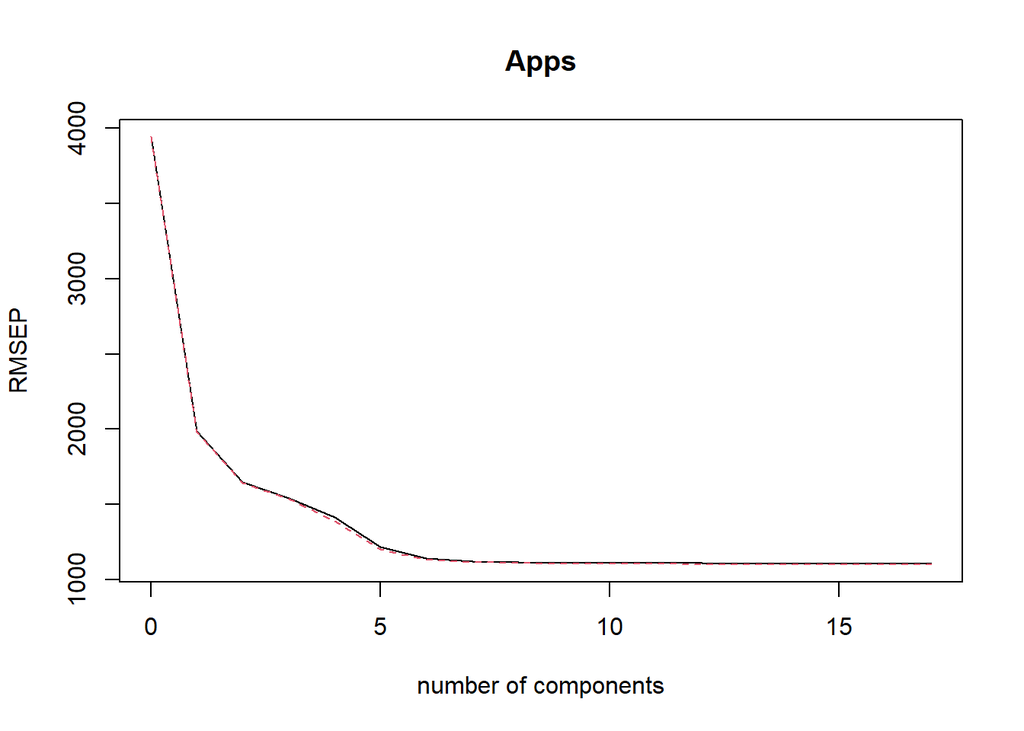

```r
pls_fit = plsr(Apps~., data=train, scale=T, validation="CV")

cat(validationplot(pls_fit, val_type="MSEP"))
```

```r
pls_pred = predict(pls_fit, test, ncomp=8)

MSE_pls = mean((test[, "Apps"] - pls_pred)^2)
cat(MSE_pls)
```

```
## 1346598
```

#### (g) Comment on the results obtained. How accurately can we predict the number of college applications received? Is there much difference among the test errors resulting from these five approaches?

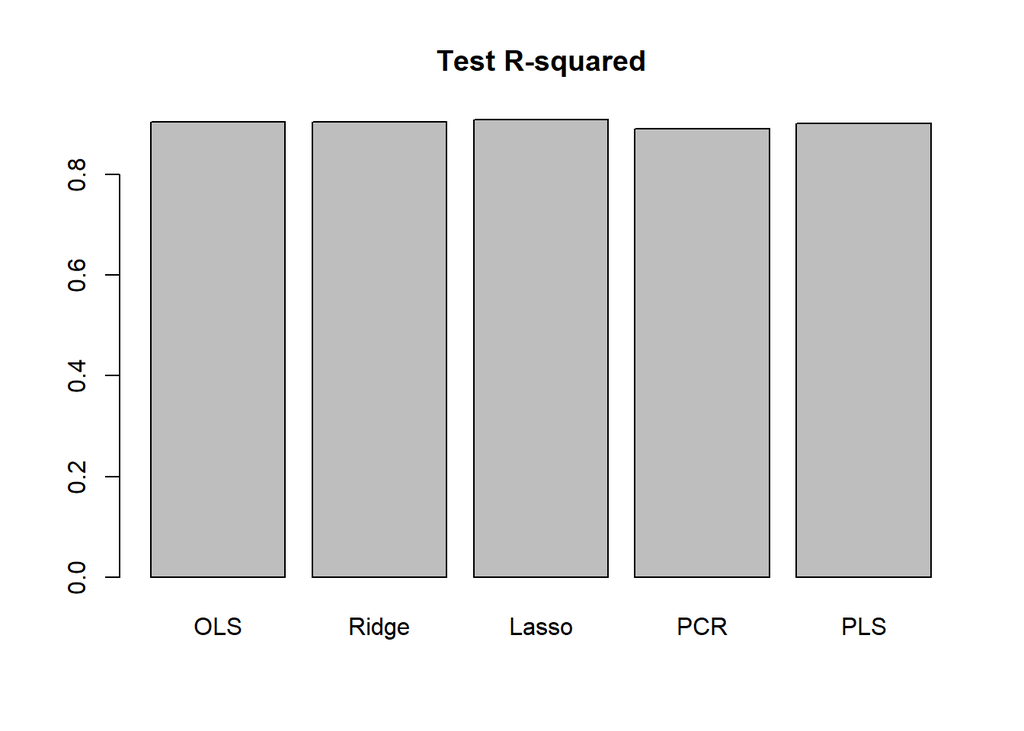

```r
avg = mean(test[, "Apps"])
mean_variance = mean((test[, "Apps"] - avg)^2)

lm_r2 = 1 - (MSE_lm /mean_variance)
ridge_r2 = 1 - (MSE_ridge/mean_variance)
lasso_r2 = 1 - (MSE_lasso/mean_variance)
pcr_r2 = 1 - (MSE_pcr/mean_variance)
pls_r2 = 1 - (MSE_pls/mean_variance)
barplot(c(lm_r2, ridge_r2, lasso_r2, pcr_r2, pls_r2), names.arg=c("OLS", "Ridge", "Lasso", "PCR", "PLS"), main="Test R-squared")
```